# pima-indians-diabetes-project

```python
# 1. Prepare Problem
# 1.a) Load libraries
import sys
import os
import pandas as pd
import numpy as np
import matplotlib.pyplot as plt
import seaborn as sns
from IPython.display import display
%matplotlib inline
import plotly.offline as py
import plotly.graph_objs as go
import plotly.tools as tls
py.init_notebook_mode(connected=True)
import warnings
warnings.filterwarnings('ignore')
from scipy.stats import skew
from scipy.stats import kurtosis

# Load libraries for evaluating algorithms
from pandas import set_option
from pandas.plotting import scatter_matrix
from sklearn.preprocessing import StandardScaler
from sklearn.model_selection import train_test_split
from sklearn.model_selection import KFold
from sklearn.model_selection import StratifiedKFold
from sklearn.model_selection import cross_val_score
from sklearn.model_selection import GridSearchCV
from sklearn.metrics import classification_report
from sklearn.metrics import confusion_matrix
from sklearn.metrics import accuracy_score
from sklearn.pipeline import Pipeline
from sklearn.linear_model import LogisticRegression
from sklearn.tree import DecisionTreeClassifier
from sklearn.neighbors import KNeighborsClassifier
from sklearn.discriminant_analysis import LinearDiscriminantAnalysis
from sklearn.naive_bayes import GaussianNB
from sklearn.svm import SVC
from sklearn.ensemble import AdaBoostClassifier
from sklearn.ensemble import GradientBoostingClassifier
from sklearn.ensemble import RandomForestClassifier
from sklearn.ensemble import ExtraTreesClassifier
from sklearn.preprocessing import StandardScaler
from sklearn.preprocessing import MinMaxScaler

from sklearn.model_selection import GridSearchCV, RandomizedSearchCV
from sklearn.ensemble import VotingClassifier

# 1.b) Load dataset
df = pd.read_csv('/kaggle/input/pima-indians-diabetes-database/diabetes.csv')
# Getting dataframe columns names
df_name=df.columns
```

```python
# 2. Summarize Data
# 2.a) Descriptive statistics
print('dimension of data',df.shape)
df.info()
df.head()
```

```
dimension of data (768, 9)
<class 'pandas.core.frame.DataFrame'>
RangeIndex: 768 entries, 0 to 767
Data columns (total 9 columns):
Pregnancies                 768 non-null int64
Glucose                     768 non-null int64
BloodPressure               768 non-null int64
SkinThickness               768 non-null int64
Insulin                     768 non-null int64
BMI                         768 non-null float64
DiabetesPedigreeFunction    768 non-null float64
Age                         768 non-null int64
Outcome                     768 non-null int64
dtypes: float64(2), int64(7)
memory usage: 54.1 KB
```

|  | Pregnancies | Glucose | BloodPressure | SkinThickness | Insulin | BMI | DiabetesPedigreeFunction | Age | Outcome |
| --- | --- | --- | --- | --- | --- | --- | --- | --- | --- |
| 0 | 6 | 148 | 72 | 35 | 0 | 33.6 | 0.627 | 50 | 1 |
| 1 | 1 | 85 | 66 | 29 | 0 | 26.6 | 0.351 | 31 | 0 |
| 2 | 8 | 183 | 64 | 0 | 0 | 23.3 | 0.672 | 32 | 1 |
| 3 | 1 | 89 | 66 | 23 | 94 | 28.1 | 0.167 | 21 | 0 |
| 4 | 0 | 137 | 40 | 35 | 168 | 43.1 | 2.288 | 33 | 1 |

```python
df.describe()
```

|  | Pregnancies | Glucose | BloodPressure | SkinThickness | Insulin | BMI | DiabetesPedigreeFunction | Age | Outcome |
| --- | --- | --- | --- | --- | --- | --- | --- | --- | --- |
| count | 768.000000 | 768.000000 | 768.000000 | 768.000000 | 768.000000 | 768.000000 | 768.000000 | 768.000000 | 768.000000 |
| mean | 3.845052 | 120.894531 | 69.105469 | 20.536458 | 79.799479 | 31.992578 | 0.471876 | 33.240885 | 0.348958 |
| std | 3.369578 | 31.972618 | 19.355807 | 15.952218 | 115.244002 | 7.884160 | 0.331329 | 11.760232 | 0.476951 |
| min | 0.000000 | 0.000000 | 0.000000 | 0.000000 | 0.000000 | 0.000000 | 0.078000 | 21.000000 | 0.000000 |
| 25% | 1.000000 | 99.000000 | 62.000000 | 0.000000 | 0.000000 | 27.300000 | 0.243750 | 24.000000 | 0.000000 |
| 50% | 3.000000 | 117.000000 | 72.000000 | 23.000000 | 30.500000 | 32.000000 | 0.372500 | 29.000000 | 0.000000 |
| 75% | 6.000000 | 140.250000 | 80.000000 | 32.000000 | 127.250000 | 36.600000 | 0.626250 | 41.000000 | 1.000000 |
| max | 17.000000 | 199.000000 | 122.000000 | 99.000000 | 846.000000 | 67.100000 | 2.420000 | 81.000000 | 1.000000 |

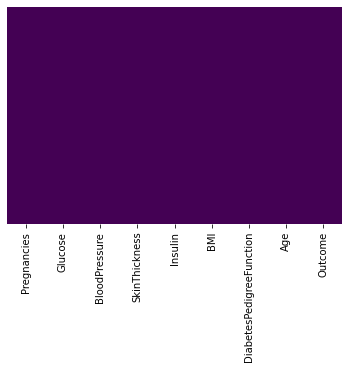

```python
# check missing values
sns.heatmap(df.isnull(),cbar=False,yticklabels=False,cmap = 'viridis')
plt.show()
```

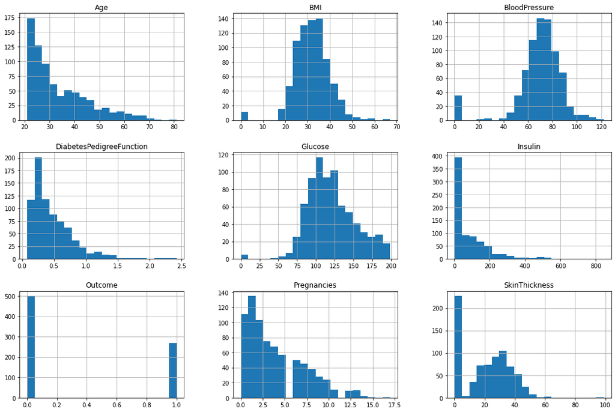

```python
# 2.b) Data visualizations:
# histogram of individual attributes
df.hist(bins=20,figsize=(18,12))
plt.show()
```

A further characterization of the data includes skewness and kurtosis.

Skewness is the degree of distortion from the symmetrical bell curve or the normal distribution. It measures the lack of symmetry in data distribution. It differentiates extreme values in one versus the other tail. A symmetrical distribution will have a skewness of 0.

Kurtosis is all about the tails of the distribution — not the peakedness or flatness. It is used to describe the extreme values in one versus the other tail. It is actually the measure of outliers present in the distribution.

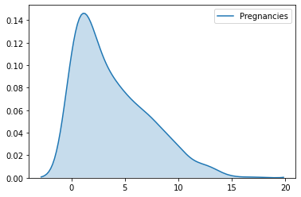

```
Pregnancies: mean (3.845052), variance (11.339272), skewness (0.899912), kurtosis (0.150383)
```

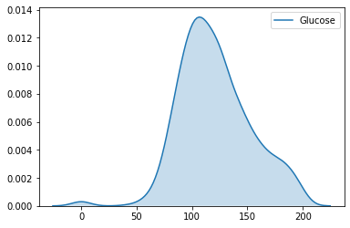

```
Glucose: mean (120.894531), variance (1020.917262), skewness (0.173414), kurtosis (0.628813)
```

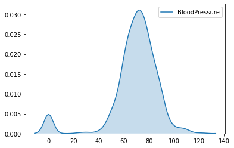

```
BloodPressure: mean (69.105469), variance (374.159449), skewness (-1.840005), kurtosis (5.138691)
```

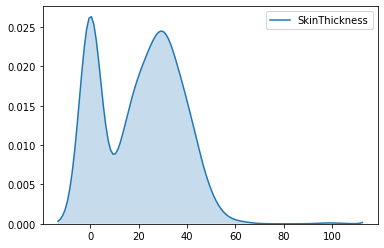

```
SkinThickness: mean (20.536458), variance (254.141900), skewness (0.109159), kurtosis (-0.524494)
```

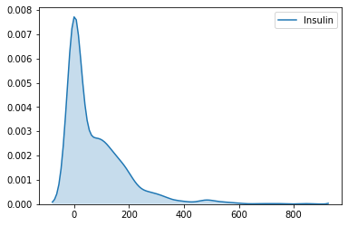

```
Insulin: mean (79.799479), variance (13263.886875), skewness (2.267810), kurtosis (7.159575)
```

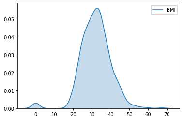

```
BMI: mean (31.992578), variance (62.079046), skewness (-0.428143), kurtosis (3.261257)
```

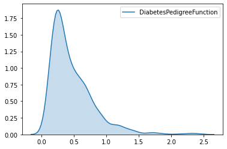

```
DiabetesPedigreeFunction: mean (0.471876), variance (0.109636), skewness (1.916159), kurtosis (5.550792)
```

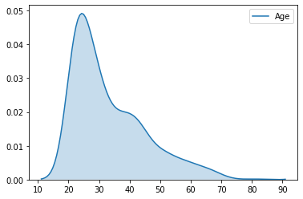

```
Age: mean (33.240885), variance (138.122964), skewness (1.127389), kurtosis (0.631177)
```

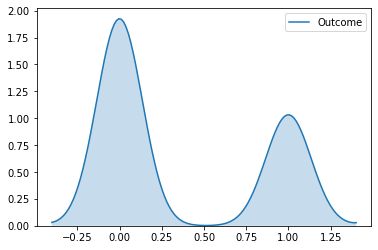

```
Outcome: mean (0.348958), variance (0.227186), skewness (0.633776), kurtosis (-1.598328)
```

```python
# density, skewness and kurtosis of each attribute
for i in range(len(df.columns)):
    sns.kdeplot(df[df_name[i]], shade=True);
    plt.show()
    print("%s: mean (%f), variance (%f), skewness (%f), kurtosis (%f)" % (df_name[i], np.mean(df[df_name[i]]), np.var(df[df_name[i]]), skew(df[df_name[i]]), kurtosis(df[df_name[i]])))
```

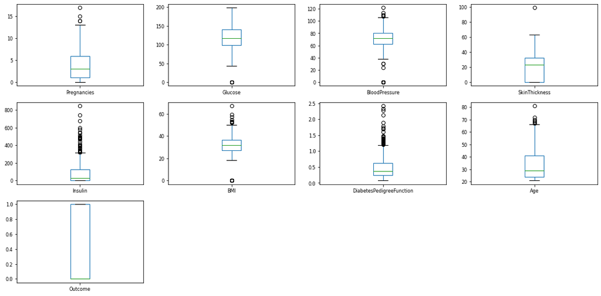

```python
# box and whisker plots
df.plot(kind= 'box', subplots=True, layout=(4,4), sharex=False, sharey=False,fontsize=8,figsize=(18,12))
plt.show()
```

From above, it looks like Insulin, DiabetesPedigreeFunction, Age and Pregnancies are skewed Gaussian distributions, and some attributes like BloodPressure, DiabetesPedigreeFunction, Insulin, BMI, Glucose and SkinThickness depict possible outliers.

```python
#  checking the target distribution
print(df.groupby('Outcome').size())
OutLabels = [str(df['Outcome'].unique()[i]) for i in range(df['Outcome'].nunique())]
OutValues = [df['Outcome'].value_counts()[i] for i in range(df['Outcome'].nunique())]
pie=go.Pie(labels=OutLabels,values=OutValues)
py.iplot([pie])
```

```
Outcome
0    500
1    268
dtype: int64
```

[interactive chart not shown]

In Feature selection, if there are two highly corrolated features we have to drop the one that has more corrolation with other features. because highly corrolated attributes result in the problem of overfitting. Let's visualise the correlation between attributes.

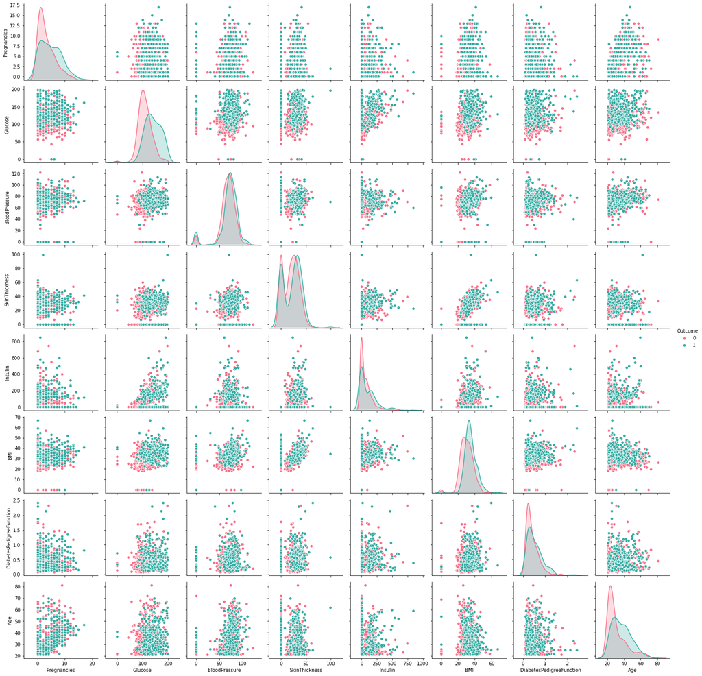

```python
# visualizations of the interactions between variables :
sns.pairplot(df, hue="Outcome", palette='husl')
plt.show()
```

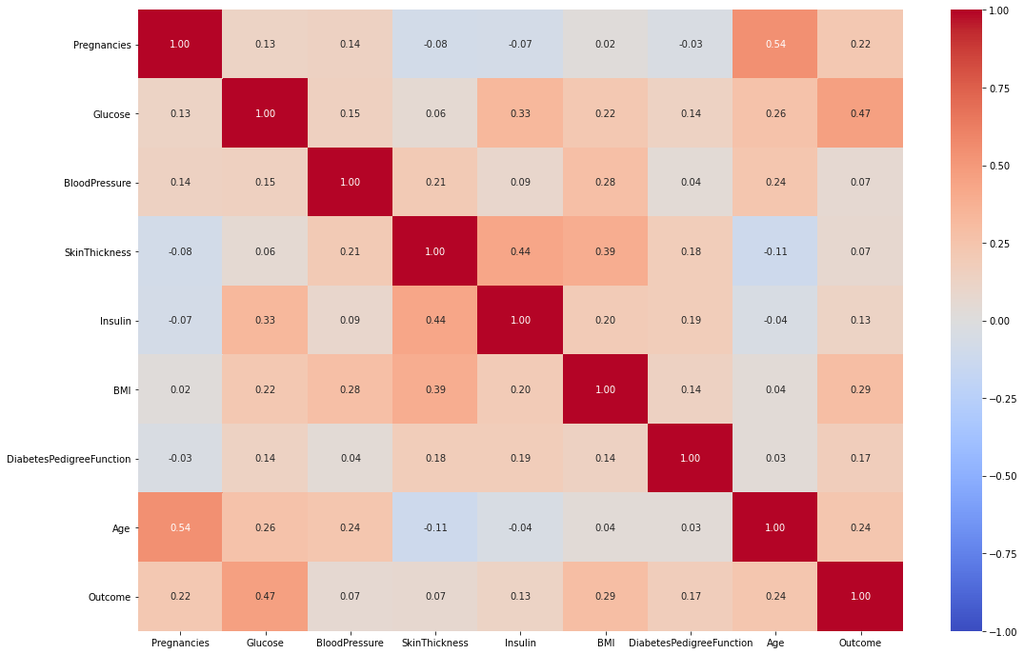

```python
fig, ax = plt.subplots(figsize=(18, 12))
ax = sns.heatmap(df.corr(),vmin=-1, vmax=1, annot=True, fmt='.2f', cmap='coolwarm')
plt.show()
```

As shown, there is no highly corrolated features.

```python
# 4. Evaluate Algorithms
# 4.a) Split-out validation dataset
X =  df[df_name[0:8]]
Y = df[df_name[8]]
X_train, X_test, y_train, y_test =train_test_split(X,Y,test_size=0.2,random_state=1,stratify=df['Outcome'])
# stratify is used to keep the same distribution of 'Outcome' in the train and test dataset
```

The diﬀering scales of the data may be negatively impacting the skill of the algorithms. Let’s evaluate the algorithms with a standardized copy of the dataset.

The preprocessing types used are :

- MinMax scaler to [0,1]
- Standard Scaler to mean = 0 and std =1

```
          Model  Score-mean     Model_2  Score-mean_2
0    standardLR    0.773612    minmaxLR      0.778556
1   standardLDA    0.775251   minmaxLDA      0.775251
2   standardKNN    0.744474   minmaxKNN      0.737784
3  standardCART    0.692041  minmaxCART      0.695267
4    standardNB    0.763723    minmaxNB      0.763723
5   standardSVM    0.776943   minmaxSVM      0.775278
6    standardAB    0.742834    minmaxAB      0.742834
7   standardGBM    0.760576   minmaxGBM      0.760603
8    standardRF    0.780116    minmaxRF      0.780116
9    standardET    0.765442    minmaxET      0.765442
```

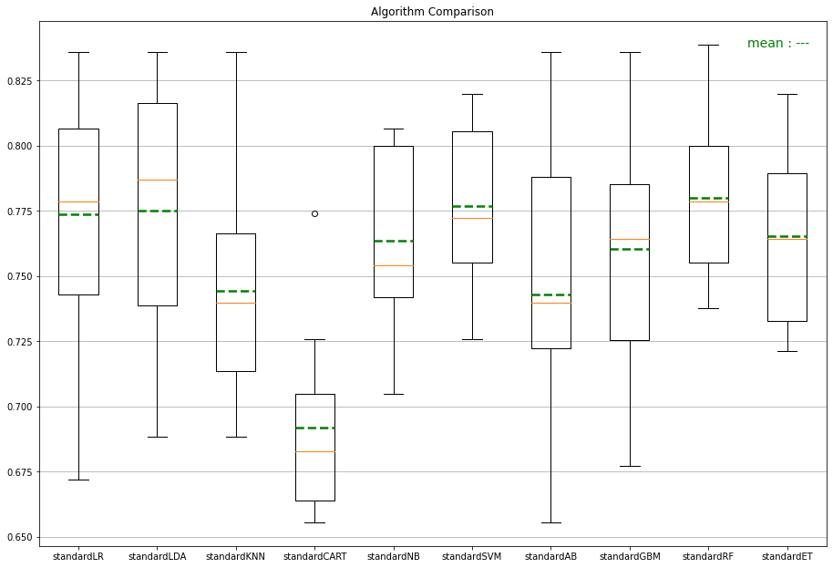

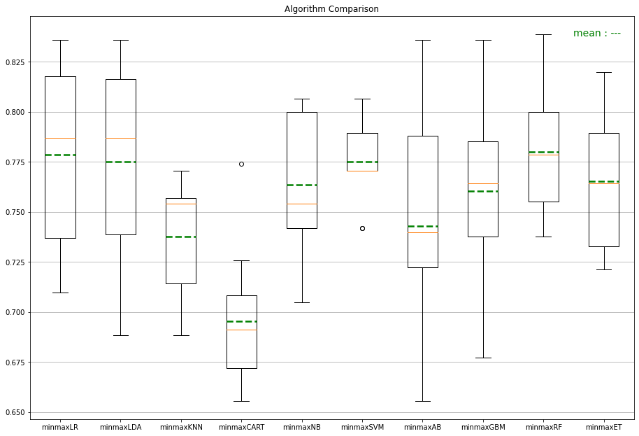

```python
# 4.b) Data Transforms & Spot-Check Algorithms
def GetScaledModel(nameOfScaler):

    if nameOfScaler == 'standard':
        scaler = StandardScaler()
    elif nameOfScaler =='minmax':
        scaler = MinMaxScaler()

    pipelines = []
    pipelines.append((nameOfScaler+'LR'  , Pipeline([('Scaler', scaler),('LR'  , LogisticRegression())])))
    pipelines.append((nameOfScaler+'LDA' , Pipeline([('Scaler', scaler),('LDA' , LinearDiscriminantAnalysis())])))
    pipelines.append((nameOfScaler+'KNN' , Pipeline([('Scaler', scaler),('KNN' , KNeighborsClassifier())])))
    pipelines.append((nameOfScaler+'CART', Pipeline([('Scaler', scaler),('CART', DecisionTreeClassifier(random_state=2))])))
    pipelines.append((nameOfScaler+'NB'  , Pipeline([('Scaler', scaler),('NB'  , GaussianNB())])))
    pipelines.append((nameOfScaler+'SVM' , Pipeline([('Scaler', scaler),('SVM' , SVC())])))
    pipelines.append((nameOfScaler+'AB'  , Pipeline([('Scaler', scaler),('AB'  , AdaBoostClassifier())])  ))
    pipelines.append((nameOfScaler+'GBM' , Pipeline([('Scaler', scaler),('GMB' , GradientBoostingClassifier(random_state=2))])  ))
    pipelines.append((nameOfScaler+'RF'  , Pipeline([('Scaler', scaler),('RF'  , RandomForestClassifier(random_state=2))])  ))
    pipelines.append((nameOfScaler+'ET'  , Pipeline([('Scaler', scaler),('ET'  , ExtraTreesClassifier(random_state=2))])  ))

    return pipelines

# Test options and evaluation metric
num_folds = 10
seed = 7
scoring = 'accuracy'

# evaluate each model in turn
def EvaluateAlg(X,y,nameOfScaler):
    results = []
    names = []
    models = GetScaledModel(nameOfScaler)
    for name, model in models:
        kfold = StratifiedKFold(n_splits=num_folds, shuffle=True, random_state=seed)
        cv_results = cross_val_score(model, X, y, cv=kfold, scoring=scoring)
        results.append(cv_results)
        names.append(name)
    return results, names

standard_results, standard_names = EvaluateAlg(X_train,y_train,'standard')
minmax_results, minmax_names = EvaluateAlg(X_train,y_train,'minmax')
score = pd.DataFrame({'Model':standard_names, 'Score-mean':[np.mean(i) for i in standard_results],
                   'Model_2':minmax_names, 'Score-mean_2':[np.mean(i) for i in minmax_results] })
print(score)

# Compare Algorithms
def CompAlg(results, names):
    fig = plt.figure()
    ax = fig.add_axes([0,0,2,2])
    ax.boxplot(results, labels=names, showmeans=True, meanline=True, meanprops = dict(linestyle='--', linewidth=2.5, color='green'))
    ax.yaxis.grid(True)
    ax.set_title('Algorithm Comparison')
    fig.text(1.8, 1.9, 'mean : ---', color='green', weight='roman',size=14)
    plt.show()

CompAlg(standard_results, standard_names)
CompAlg(minmax_results, minmax_names)
```

```python
# 4.d) Data Cleaning : outliers investigation
df_copy = df.copy()
# using box and whisker plots to visualize outliers
def OutliersBox(df,nameOfFeature):

    trace0 = go.Box(
        y = df[nameOfFeature],
        name = "All Points",
        jitter = 0.3,
        pointpos = -1.8,
        boxpoints = 'all',
        marker = dict(
            color = 'rgb(7,40,89)'),
        line = dict(
            color = 'rgb(7,40,89)')
    )

    trace1 = go.Box(
        y = df[nameOfFeature],
        name = "Only Whiskers",
        boxpoints = False,
        marker = dict(
            color = 'rgb(9,56,125)'),
        line = dict(
            color = 'rgb(9,56,125)')
    )

    trace2 = go.Box(
        y = df[nameOfFeature],
        name = "Suspected Outliers",
        boxpoints = 'suspectedoutliers',
        marker = dict(
            color = 'rgb(8,81,156)',
            outliercolor = 'rgba(219, 64, 82, 0.6)',
            line = dict(
                outliercolor = 'rgba(219, 64, 82, 0.6)',
                outlierwidth = 2)),
        line = dict(
            color = 'rgb(8,81,156)')
    )

    data = [trace0,trace1,trace2]

    layout = go.Layout(title = "{} Outliers".format(nameOfFeature))

    go.Figure(data=data,layout=layout).show()

# function to remove outliers
def DropOutliers(df_copy,nameOfFeature):

    valueOfFeature = df_copy[nameOfFeature]

    # Calculate Q1 (25th percentile of the data) for the given feature
    Q1 = np.percentile(valueOfFeature, 25.)

    # Calculate Q3 (75th percentile of the data) for the given feature
    Q3 = np.percentile(valueOfFeature, 75.)

    # Use the interquartile range to calculate an outlier step (1.5 times the interquartile range)
    step = (Q3-Q1)*1.5

    # Index of outliers
    outliers_idx = valueOfFeature[~((valueOfFeature >= Q1 - step) & (valueOfFeature <= Q3 + step))].index.tolist()

    # Values of outliers
    outliers_val = valueOfFeature[~((valueOfFeature >= Q1 - step) & (valueOfFeature <= Q3 + step))].values

    # Remove the outliers
    print ("Number of outliers (inc duplicates): {} and outliers: {}".format(len(outliers_idx), outliers_val))
    good_data = df_copy.drop(df_copy.index[outliers_idx]).reset_index(drop = True)
    print ("New dataset with removed outliers has {} samples with {} features each.".format(*good_data.shape))
    return good_data
```

```python
outliers_clmn=['BloodPressure', 'DiabetesPedigreeFunction', 'Insulin', 'BMI', 'Glucose', 'SkinThickness']
df_clean=df_copy
for i in range(len(outliers_clmn)):
    OutliersBox(df,outliers_clmn[i])
    df_clean = DropOutliers(df_clean,outliers_clmn[i])
    OutliersBox(df_clean,outliers_clmn[i])
```

[interactive chart not shown]

```
Number of outliers (inc duplicates): 45 and outliers: [  0   0  30 110   0   0   0   0 108 122  30   0 110   0   0   0   0   0
   0   0   0   0   0 108   0   0   0   0   0   0   0   0   0   0 110   0
  24   0   0   0   0 114   0   0   0]
New dataset with removed outliers has 723 samples with 9 features each.
```

[interactive chart not shown]

```
Number of outliers (inc duplicates): 29 and outliers: [2.288 1.441 1.39  1.893 1.781 1.222 1.4   1.321 1.224 2.329 1.318 1.213
 1.353 1.224 1.391 1.476 2.137 1.731 1.268 1.6   2.42  1.251 1.699 1.258
 1.282 1.698 1.461 1.292 1.394]
New dataset with removed outliers has 694 samples with 9 features each.
```

[interactive chart not shown]

```
Number of outliers (inc duplicates): 28 and outliers: [543 846 342 495 485 495 478 370 680 402 375 545 360 415 579 474 328 480
 326 330 600 440 540 480 335 387 392 510]
New dataset with removed outliers has 666 samples with 9 features each.
```

[interactive chart not shown]

```
Number of outliers (inc duplicates): 9 and outliers: [ 0.  49.7 53.2  0.  50.  52.9 57.3 49.6  0. ]
New dataset with removed outliers has 657 samples with 9 features each.
```

[interactive chart not shown]

```
Number of outliers (inc duplicates): 13 and outliers: [196   0   0 196   0   0 196 197 195   0 198 197 195]
New dataset with removed outliers has 644 samples with 9 features each.
```

[interactive chart not shown]

```
Number of outliers (inc duplicates): 0 and outliers: []
New dataset with removed outliers has 644 samples with 9 features each.
```

[interactive chart not shown]

```python
# Comparing the accuracy of models after removing outliers
df_clean_name = df_clean.columns
X_c =  df_clean[df_clean_name[0:8]]
Y_c = df_clean[df_clean_name[8]]
X_train_c, X_test_c, y_train_c, y_test_c =train_test_split(X_c,Y_c,test_size=0.2, random_state=0, stratify=df_clean['Outcome'])

standard_results_c, standard_names_c = EvaluateAlg(X_train_c,y_train_c,'standard')
minmax_results_c, minmax_names_c = EvaluateAlg(X_train_c,y_train_c,'minmax')

score_c = pd.DataFrame({'Model-s_c':standard_names_c, 'Score-s_c':[np.mean(i) for i in standard_results_c],
                        'Model-m_c':minmax_names_c, 'Score-m_c':[np.mean(i) for i in minmax_results_c]})
score=pd.concat([score,score_c],axis=1)
```

```python
score
```

|  | Model | Score-mean | Model_2 | Score-mean_2 | Model-s_c | Score-s_c | Model-m_c | Score-m_c |
| --- | --- | --- | --- | --- | --- | --- | --- | --- |
| 0 | standardLR | 0.773612 | minmaxLR | 0.778556 | standardLR | 0.794080 | minmaxLR | 0.792195 |
| 1 | standardLDA | 0.775251 | minmaxLDA | 0.775251 | standardLDA | 0.788198 | minmaxLDA | 0.788198 |
| 2 | standardKNN | 0.744474 | minmaxKNN | 0.737784 | standardKNN | 0.739555 | minmaxKNN | 0.716290 |
| 3 | standardCART | 0.692041 | minmaxCART | 0.695267 | standardCART | 0.726056 | minmaxCART | 0.726056 |
| 4 | standardNB | 0.763723 | minmaxNB | 0.763723 | standardNB | 0.751659 | minmaxNB | 0.751659 |
| 5 | standardSVM | 0.776943 | minmaxSVM | 0.775278 | standardSVM | 0.764894 | minmaxSVM | 0.770777 |
| 6 | standardAB | 0.742834 | minmaxAB | 0.742834 | standardAB | 0.751659 | minmaxAB | 0.751659 |
| 7 | standardGBM | 0.760576 | minmaxGBM | 0.760603 | standardGBM | 0.769005 | minmaxGBM | 0.770965 |
| 8 | standardRF | 0.780116 | minmaxRF | 0.780116 | standardRF | 0.768854 | minmaxRF | 0.768854 |
| 9 | standardET | 0.765442 | minmaxET | 0.765442 | standardET | 0.755204 | minmaxET | 0.755204 |

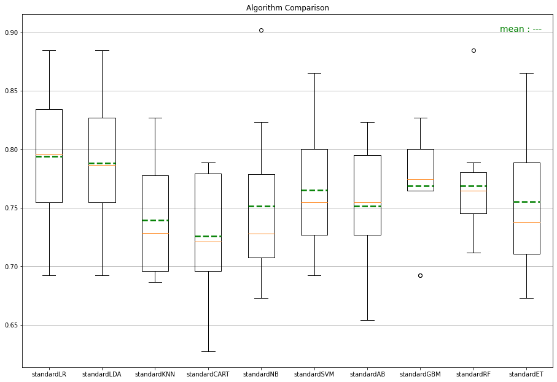

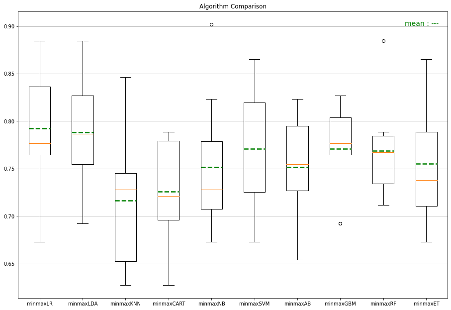

```python
CompAlg(standard_results_c, standard_names_c)
CompAlg(minmax_results_c, minmax_names_c)
```

Irrelevant features can negatively impact model performance. Identifying and removing uneeded and irrelevant feature will enhance the performance of the model. As shown previously, the correlation between attribute didn't say too much, so estimating the importance of features using Bagged decision trees like Random Forest and Extra Trees can yield good results.

```python
# 4.e) Feature selection:

clf = ExtraTreesClassifier(n_estimators=250,random_state=2)
clf.fit(X_train_c, y_train_c)

# feature importance
feature_importance = clf.feature_importances_
# make importances relative to max importance
feature_importance = 100.0 * (feature_importance / feature_importance.max())
# indexes from min to max value
sorted_idx = np.argsort(feature_importance)

Variable_importance = pd.DataFrame({'feature':df_clean_name[sorted_idx],'Relative Importance':feature_importance[sorted_idx]})
print(Variable_importance)
```

```
                    feature  Relative Importance
0                   Insulin            32.991898
1             SkinThickness            33.093575
2             BloodPressure            44.110316
3  DiabetesPedigreeFunction            47.594673
4               Pregnancies            49.731324
5                       BMI            57.442616
6                       Age            60.476953
7                   Glucose           100.000000
```

We can see that Insulin and SkinThickness are relatively less important than the rest of features, so droping these features could improve the model performance.

```
  Model-m_c_imp  Score-m_c_imp
0      minmaxLR       0.794118
1     minmaxLDA       0.784389
2     minmaxKNN       0.759125
3    minmaxCART       0.734163
4      minmaxNB       0.763235
5     minmaxSVM       0.784314
6      minmaxAB       0.763311
7     minmaxGBM       0.778733
8      minmaxRF       0.792081
9      minmaxET       0.786312
```

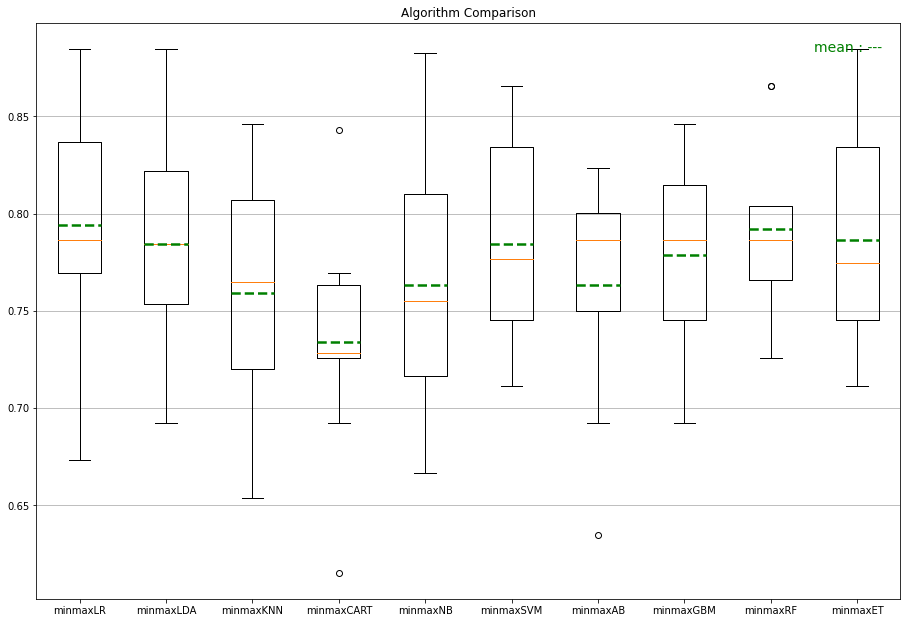

```python
df_feature_imp=df_clean.drop(['Insulin','SkinThickness'], axis=1)
df_feature_imp_name = df_feature_imp.columns

X =  df_feature_imp[df_feature_imp_name[0:6]]
Y = df_feature_imp[df_feature_imp_name[6]]
X_train_c_imp, X_test_c_imp, y_train_c_imp, y_test_c_imp =train_test_split(X,Y,test_size=0.2,random_state=0,stratify=df_feature_imp['Outcome'])

minmax_results_c_imp, minmax_names_c_imp = EvaluateAlg(X_train_c_imp,y_train_c_imp,'minmax')

score_c_imp = pd.DataFrame({'Model-m_c_imp':minmax_names_c_imp, 'Score-m_c_imp':[np.mean(i) for i in minmax_results_c_imp]})
print(score_c_imp)

CompAlg(minmax_results_c_imp, minmax_names_c_imp)
score=pd.concat([score,score_c_imp],axis=1)
```

```python
score
```

|  | Model | Score-mean | Model_2 | Score-mean_2 | Model-s_c | Score-s_c | Model-m_c | Score-m_c | Model-m_c_imp | Score-m_c_imp |
| --- | --- | --- | --- | --- | --- | --- | --- | --- | --- | --- |
| 0 | standardLR | 0.773612 | minmaxLR | 0.778556 | standardLR | 0.794080 | minmaxLR | 0.792195 | minmaxLR | 0.794118 |
| 1 | standardLDA | 0.775251 | minmaxLDA | 0.775251 | standardLDA | 0.788198 | minmaxLDA | 0.788198 | minmaxLDA | 0.784389 |
| 2 | standardKNN | 0.744474 | minmaxKNN | 0.737784 | standardKNN | 0.739555 | minmaxKNN | 0.716290 | minmaxKNN | 0.759125 |
| 3 | standardCART | 0.692041 | minmaxCART | 0.695267 | standardCART | 0.726056 | minmaxCART | 0.726056 | minmaxCART | 0.734163 |
| 4 | standardNB | 0.763723 | minmaxNB | 0.763723 | standardNB | 0.751659 | minmaxNB | 0.751659 | minmaxNB | 0.763235 |
| 5 | standardSVM | 0.776943 | minmaxSVM | 0.775278 | standardSVM | 0.764894 | minmaxSVM | 0.770777 | minmaxSVM | 0.784314 |
| 6 | standardAB | 0.742834 | minmaxAB | 0.742834 | standardAB | 0.751659 | minmaxAB | 0.751659 | minmaxAB | 0.763311 |
| 7 | standardGBM | 0.760576 | minmaxGBM | 0.760603 | standardGBM | 0.769005 | minmaxGBM | 0.770965 | minmaxGBM | 0.778733 |
| 8 | standardRF | 0.780116 | minmaxRF | 0.780116 | standardRF | 0.768854 | minmaxRF | 0.768854 | minmaxRF | 0.792081 |
| 9 | standardET | 0.765442 | minmaxET | 0.765442 | standardET | 0.755204 | minmaxET | 0.755204 | minmaxET | 0.786312 |

We still could improve the prediction with algorithm tuning

```python
# 5. Improve Accuracy
# 5.a) Algorithm Tuning

def GridSearch(X_train,y_train,model,hyperparameters):
    kfold = StratifiedKFold(n_splits=num_folds, shuffle=True, random_state=seed)
    clf = GridSearchCV(estimator=model,param_grid=hyperparameters,scoring=scoring,cv=kfold)
    # Fit grid search
    best_model = clf.fit(X_train, y_train)
    message = (best_model.best_score_, best_model.best_params_)
    print("Best: %f using %s" % (message))

    return best_model,best_model.best_params_
```

Logistic Regression (LR) :

C : Regularization value.  
penalty : Can be either "L2" or “L1”. Default is “L2”.

```python
# model
model = Pipeline([('MinMaxScaler', MinMaxScaler()),('LR', LogisticRegression())])
# create regularization penalty space
penalty = ['l1', 'l2']
# create regularization hyperparameter distribution using uniform distribution
C = [0.01,0.1,0.5,1,1.2,1.4,1.6]
# Create hyperparameter options
hyperparameters = dict(LR__C=C,LR__penalty=penalty)

LR = GridSearch(X_train_c_imp,y_train_c_imp,model,hyperparameters)
#LR_best_model,LR_best_params = GridSearch.GridSearch()
```

```
Best: 0.798002 using {'LR__C': 1.2, 'LR__penalty': 'l2'}
```

KNeighborsClassifier (KNN) :

n_neighbors: Number of neighbors.

```python
model = Pipeline([('MinMaxScaler', MinMaxScaler()),('KNN', KNeighborsClassifier())])

neighbors = [1,2,3,4,5,6,7,8,9,10,11,12,13,14,15,16,17,18,19,20]
hyperparameters = dict(KNN__n_neighbors=neighbors)

KNN = GridSearch(X_train_c_imp,y_train_c_imp,model,hyperparameters)
```

```
Best: 0.768665 using {'KNN__n_neighbors': 7}
```

SVC :

C: The Penalty parameter C of the error term.  
Kernel: Kernel type could be linear, poly, rbf or sigmoid.

```python
model = Pipeline([('MinMaxScaler', MinMaxScaler()),('SVM', SVC())])

c_values = [0.1, 0.3, 0.5, 0.7, 0.9, 1.0, 1.3, 1.5, 1.7, 2.0]
kernel_values = [ 'linear' , 'poly' , 'rbf' , 'sigmoid' ]
hyperparameters = dict(SVM__C=c_values, SVM__kernel=kernel_values)

SVC = GridSearch(X_train_c_imp,y_train_c_imp,model,hyperparameters)
```

```
Best: 0.794118 using {'SVM__C': 0.1, 'SVM__kernel': 'poly'}
```

DecisionTreeClassifier (CART) :

max_depth: Maximum depth of the tree (double).  
row_subsample: Proportion of observations to consider (double).  
max_features: Proportion of columns (features) to consider in each level (double).

```python
model = Pipeline([('MinMaxScaler', MinMaxScaler()),('CART', DecisionTreeClassifier(random_state=2))])

max_depth_value = [2,3,4, None]
max_features_value =  [1,2,3,4]
min_samples_leaf_value = [1,2,3,4]
criterion_value = ["gini", "entropy"]

hyperparameters = dict(CART__max_depth = max_depth_value,
                  CART__max_features = max_features_value,
                  CART__min_samples_leaf = min_samples_leaf_value,
                  CART__criterion = criterion_value)

CART = GridSearch(X_train_c_imp,y_train_c_imp,model,hyperparameters)
```

```
Best: 0.778582 using {'CART__criterion': 'entropy', 'CART__max_depth': 2, 'CART__max_features': 3, 'CART__min_samples_leaf': 1}
```

AdaBoostClassifier (AB) :

learning_rate: Learning rate shrinks the contribution of each classifier by learning_rate.  
n_estimators: Number of trees to build.

```python
model = Pipeline([('MinMaxScaler', MinMaxScaler()),('AB', AdaBoostClassifier())])

learning_rate_value = [.01,.05,.1,.5,1]
n_estimators_value = [50,100,150,200,250,300]

hyperparameters = dict(AB__learning_rate=learning_rate_value, AB__n_estimators=n_estimators_value)

AB = GridSearch(X_train_c_imp,y_train_c_imp,model,hyperparameters)
```

```
Best: 0.796192 using {'AB__learning_rate': 0.05, 'AB__n_estimators': 200}
```

GradientBoostingClassifier (GMB)

```python
model = Pipeline([('MinMaxScaler', MinMaxScaler()),('GMB', GradientBoostingClassifier(random_state=2))])

learning_rate_value = [.01,.05,.1,.5,1]
n_estimators_value = [50,100,150,200,250,300]

hyperparameters = dict(GMB__learning_rate=learning_rate_value, GMB__n_estimators=n_estimators_value)

GMB = GridSearch(X_train_c_imp,y_train_c_imp,model,hyperparameters)
```

```
Best: 0.790271 using {'GMB__learning_rate': 0.5, 'GMB__n_estimators': 50}
```

ExtraTreesClassifier (ET) :

n_estimators: Number of trees to build.

```python
model = Pipeline([('Scaler', StandardScaler()),('ET', ExtraTreesClassifier(random_state=2))])

n_estimators_value = [50,60,80,100]
max_features_value =  [2,3]
min_samples_leaf_value = [2,4]
criterion_value = ["gini", "entropy"]

hyperparameters = dict(ET__n_estimators = n_estimators_value,
                  ET__max_features = max_features_value,
                  ET__min_samples_leaf = min_samples_leaf_value,
                  ET__criterion = criterion_value)

ET = GridSearch(X_train_c_imp,y_train_c_imp,model,hyperparameters)
```

```
Best: 0.796078 using {'ET__criterion': 'entropy', 'ET__max_features': 3, 'ET__min_samples_leaf': 4, 'ET__n_estimators': 60}
```

Voting Ensemble :

Voting is one of the simplest ways of combining the predictions from multiple machine learning algorithms. It works by first creating two or more standalone models from your training dataset. A Voting Classifier can then be used to wrap your models and average the predictions of the sub-models when asked to make predictions for new data.

```python
from sklearn.svm import SVC
# 5.b) Ensembles

model1 = LogisticRegression(C=1.2, penalty='l2')

model2 = KNeighborsClassifier(n_neighbors= 7)

model3 = SVC(C =0.1, kernel='poly')

model4 = DecisionTreeClassifier(criterion='entropy', max_depth= 2, max_features=3, min_samples_leaf= 1,random_state=2)

model5 = AdaBoostClassifier(learning_rate= 0.05, n_estimators=200)

model6 = GradientBoostingClassifier(learning_rate=0.5, n_estimators=50,random_state= 2)

model7 = GaussianNB()

model8 = RandomForestClassifier(random_state = 2)

model9 = ExtraTreesClassifier(criterion='entropy', n_estimators= 60, max_features=3, min_samples_leaf= 4,random_state=2)

# create the sub models
estimators = []
estimators.append(('MinMax '+'LR'  , Pipeline([('Scaler', MinMaxScaler()),('LR'  , model1)])))
estimators.append(('MinMax '+'KNN' , Pipeline([('Scaler', MinMaxScaler()),('KNN' , model2)])))
estimators.append(('MinMax '+'SVM' , Pipeline([('Scaler', MinMaxScaler()),('SVM' , model3)])))
estimators.append(('MinMax '+'CART', Pipeline([('Scaler', MinMaxScaler()),('CART', model4)])))
estimators.append(('MinMax '+'AB'  , Pipeline([('Scaler', MinMaxScaler()),('AB'  , model5)])  ))
estimators.append(('MinMax '+'GBM' , Pipeline([('Scaler', MinMaxScaler()),('GMB' , model6)])  ))
estimators.append(('MinMax '+'NB' , Pipeline([('Scaler', MinMaxScaler()),('NB' , model7)])  ))
estimators.append(('MinMax '+'RF'  , Pipeline([('Scaler', MinMaxScaler()),('RF'  , model8)])  ))
estimators.append(('MinMax '+'ET'  , Pipeline([('Scaler', MinMaxScaler()),('ET'  , model9)])  ))


kfold = StratifiedKFold(n_splits=num_folds, random_state=seed, shuffle=True)
ensemble = VotingClassifier(estimators)
results = cross_val_score(ensemble, X_train_c_imp, y_train_c_imp, cv=kfold)
print('Accuracy on train: ',results.mean())
```

```
Accuracy on train:  0.7941176470588236
```

Finalize model :

We will use the Voting Ensemble to make prediction on the test set.

```python
# 6. Finalize Model : Predictions on test dataset

# prepare the model : training the model on the entire training dataset
sc = MinMaxScaler()
rescaledX = sc.fit_transform(X_train_c_imp)
model = VotingClassifier(estimators)
model.fit(rescaledX, y_train_c_imp)

# transform the test dataset
rescaledTestX = sc.transform(X_test_c_imp)
predictions = model.predict(rescaledTestX)

# Evaluate predictions
print(accuracy_score(y_test_c_imp, predictions))
print(confusion_matrix(y_test_c_imp, predictions))
print(classification_report(y_test_c_imp, predictions))
```

```
0.7829457364341085
[[83  6]
 [22 18]]
              precision    recall  f1-score   support

           0       0.79      0.93      0.86        89
           1       0.75      0.45      0.56        40

    accuracy                           0.78       129
   macro avg       0.77      0.69      0.71       129
weighted avg       0.78      0.78      0.76       129
```